# Inicio de un proyecto de análisis de datos con R

Métodos de análisis no paramétricos

Dr. José A. Gallardo.

Profesor adjunto de la Pontificia Universidad Católica de Valparaíso  
jose.gallardo@pucv.cl

March 22, 2021

#### Objetivos de aprendizaje

1.- Iniciar un proyecto de análisis de datos con R usando el software **[Rstudio.Cloud](https://rstudio.cloud/)**.

2.- Escribir un código de programación con el **[software R](https://www.r-project.org/about.html)** para simular datos de una variable aleatoria con distribución nornal.

#### Conceptos importantes

**Variables:** Características que se pueden medir en un individuo o en un ambiente.

**Datos:** Son los valores que puede tomar una variable o las mediciones que se hace de las características de un individuo o su ambiente.

**Variable aleatoria:** Es una variable cuyo valor se determina por el azar. Las variables aleatorias se representan por letras mayúsculas y sus valores numéricos por letras minúsculas.

#### Software.

**R** R es un lenguaje de programación orientado a *objetos*.

```r
R.version.string
```

```
## [1] "R version 4.0.3 (2020-10-10)"
```

#### Librerías.

**{stats}**, **{base}**, **{graphics}**

#### Comandos y argumentos.

**library()**  
Este comando permite instalar librerías en R.  
Ejemplo: *library(stats)*

**<-**  
Este comando permite crear objetos. Por ejemplo, el siguiente código crea un objeto llamado datos con 4 elementos denominados 1,2,3 y 4.  
*datos <- c(1,2,3,4)*

**set.seed()**  
Establece una semilla o punto de inicio para la generación de números aleatorios. Permite obtener resultados reproducibles cada vez.

**rnorm(n, mean, sd)**  
Genera (n) números aleatorios con una distribución normal con promedio (mean) y desviación estandar (sd).

**dnorm(x, mean, sd)**  
Genera la distribución de probabilidad de un conjunto de valores (x) con promedio *mean* y desviasion estandar *sd*.

**pnorm(q, mean, sd)**  
Genera la distribución de probabilidad acumulada de un conjunto de valores (q) con promedio *mean* y desviasion estandar *sd*.

**hist(x)**  
Genera el histograma de un conjunto de valores x.

**plot(x, y)**  
Función genérica para generar gráficos x-y

**mean()** Función para calcular el promedio.

**sd()** Función para calcular la desviasión estandar.

#### EJERCICIOS

**Ejercicio 1.** Elabore un archivo Rmarkdown o file con extensión **.Rmd** en Rstudio o Rstudio.cloud y configurelo para exportar el resultado como un documento dinámico **pdf**.

En el primier bloque de códigos o **chunk** configure los comandos de la siguiente manera *knitr::opts_chunk$set(echo = TRUE)* y cargue las librerías **stats**, **base** y **graphics** usando la función library(). Ejecute el comando help en la consola e investigue las funciones contenidas en cada librería.

```r
knitr::opts_chunk$set(echo = TRUE)

library(stats)
library(base)
library(graphics)

help(stats)
help(base)
help(graphics)
```

**Ejercicio 2.** Borre los bloques de códigos R que se generan automáticamente con cada archivo .Rmd y reemplacelos por 5 nuevos bloques de códigos con el botón verde **+C** que se encuentra en la parte superior del panel de códigos. Ejecute cada uno de los siguientes ejercicios en un bloque de códigos diferente.

**Ejercicio 3.** Simule una muestra aletoria de 100 peces de la especie salmón del Atlántico (*Salmo salar*) con promedio 5 Kg y con desviación estandar de 0,8 Kg (use punto para representar el decimal: 0.8). Establesca una semilla de 123 usando la función set.seed()

```r
set.seed(123)
rnorm(100, 5, 0.8)
```

```
##   [1] 4.551619 4.815858 6.246967 5.056407 5.103430 6.372052 5.368733 3.987951
##   [9] 4.450518 4.643470 5.979265 5.287851 5.320617 5.088546 4.555327 6.429531
##  [17] 5.398280 3.426706 5.561085 4.621767 4.145741 4.825620 4.179196 4.416887
##  [25] 4.499969 3.650645 5.670230 5.122698 4.089490 6.003052 5.341171 4.763943
##  [33] 5.716101 5.702507 5.657265 5.550912 5.443134 4.950471 4.755230 4.695623
##  [41] 4.444234 4.833666 3.987683 6.735165 5.966370 4.101513 4.677692 4.626676
##  [49] 5.623972 4.933305 5.202655 4.977163 4.965704 6.094882 4.819383 6.213176
##  [57] 3.760998 5.467691 5.099083 5.172753 5.303712 4.598141 4.733434 4.185140
##  [65] 4.142567 5.242823 5.358568 5.042403 5.737814 6.640068 4.607175 3.152665
##  [73] 5.804591 4.432639 4.449593 5.820457 4.772182 4.023426 5.145043 4.888887
##  [81] 5.004611 5.308224 4.703472 5.515501 4.823611 5.265426 5.877471 5.348145
##  [89] 4.739255 5.919046 5.794803 5.438718 5.190985 4.497675 6.088522 4.519792
##  [97] 6.749866 6.226089 4.811440 4.178863
```

**Ejercicio 4.** Almacene los datos de simulación en un objeto denominado **salmon** usando el comando **<-** y determine el promedio y la desvisón estandar de su muestra usando las funciones mean() y sd().

```r
set.seed(123)
salmonr <- rnorm(1000, 5, 0.8)
mean(salmonr)
```

```
## [1] 5.012902
```

```r
sd(salmonr)
```

```
## [1] 0.793356
```

**Ejercicio 5.** A partir de la simulación anterior elabore un histograma de su muestra usando la función hist(). Busque argumentos de la función hist() para incluir el título del histograma, el nombre del eje x y coloree en azúl el histograma.

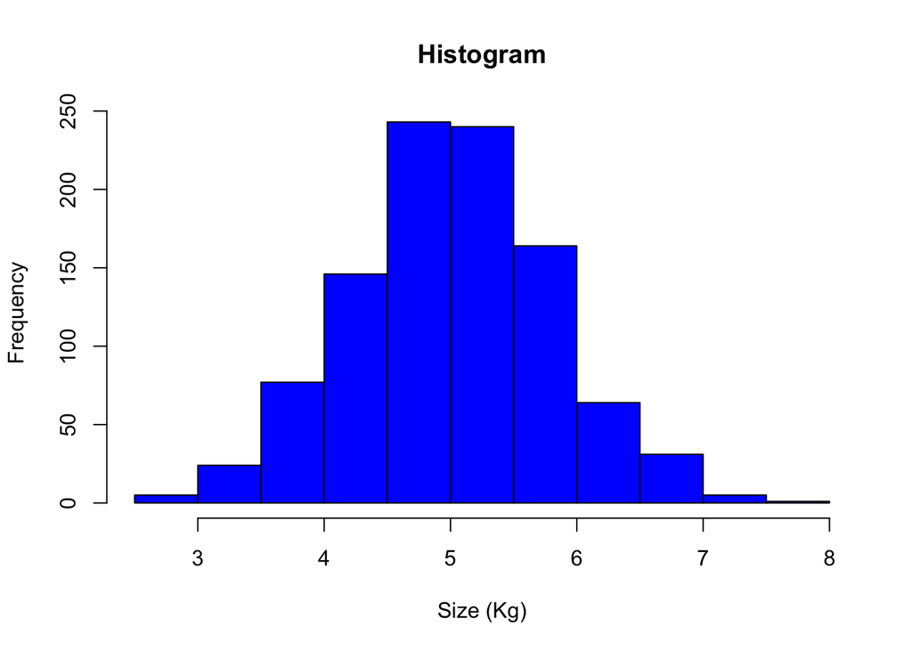

```r
hist(salmonr, col="blue", main = "Histogram", xlab = "Size (Kg)")
```

**Ejercicio 6.** Gráfique la distribución de probabilidad del conjunto de datos simulados de tamaño de salmón. Recuerde que en el eje x debe representar el valor del número aleatorio del tamaño, y en el eje y la probabilidad. Ayuda: use las funciones dnorm() y plot().

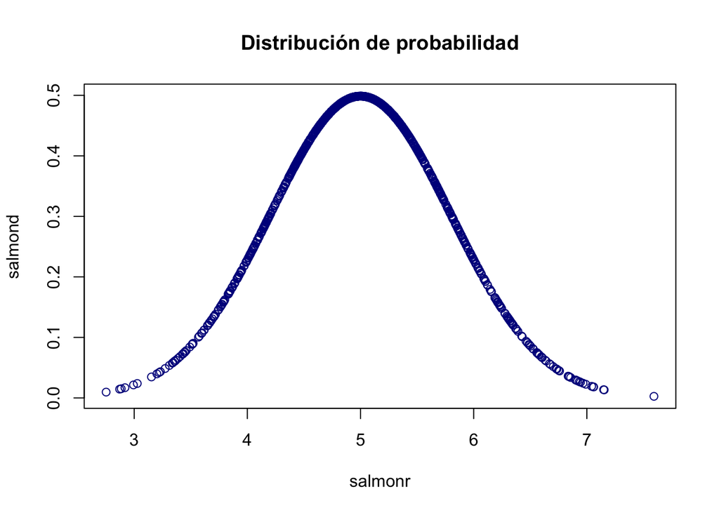

```r
salmond <- dnorm(salmonr, 5, 0.8)

plot(x=salmonr, y=salmond, main="Distribución de probabilidad", col="blue4")
```

**Ejercicio 6.** Gráfique la distribución de probabilidad acumulada del conjunto de datos simulados de tamaño de salmón. Recuerde que en el eje x debe representar el valor del número aleatorio del tamaño, y en el eje y la probabilidad acumulada. Ayuda: use las funciones pnorm() y plot().

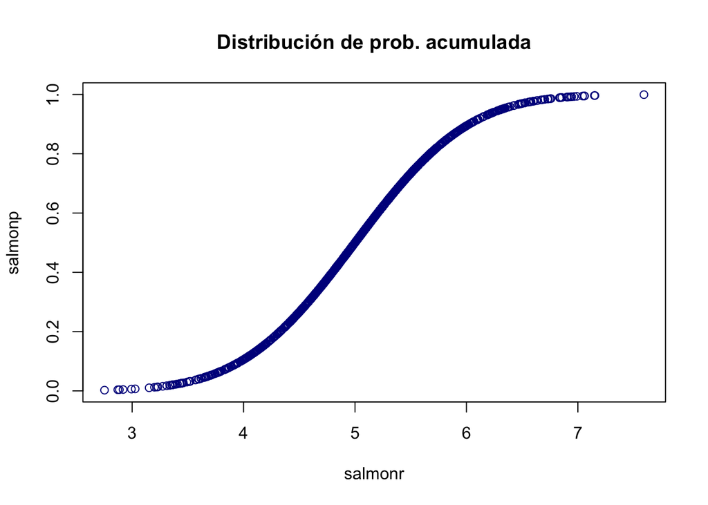

```r
salmonp<-pnorm(salmonr, 5, 0.8)

plot(x=salmonr, y=salmonp, main="Distribución de prob. acumulada", col="blue4")
```